# ML-Assignment 4

2022-11-04

```r
library(caret)
library(tidyverse)
library(factoextra)
library(esquisse)
set.seed(123)
```

```r
getwd()
```

```
## [1] "/Users/thupiliabhinav/Desktop/ML/ML- Assignment 4"
```

```r
setwd("/Users/thupiliabhinav/Desktop/ML/ML- Assignment 4")
pharma <- read.csv("Pharmaceuticals.csv")
```

#a. Using only the numerical variables (1 to 9) to cluster the 21.

```r
norm_mean<- pharma %>% select('Market_Cap', 'Beta', 'PE_Ratio', 'ROE', 'ROA', 'Asset_Turnover', 'Leverage', 'Rev_Growth', 'Net_Profit_Margin')

#Scaling the Data.
norm_train <- preProcess(norm_mean, method = "range")
norm_predict<-predict(norm_train, norm_mean)
```

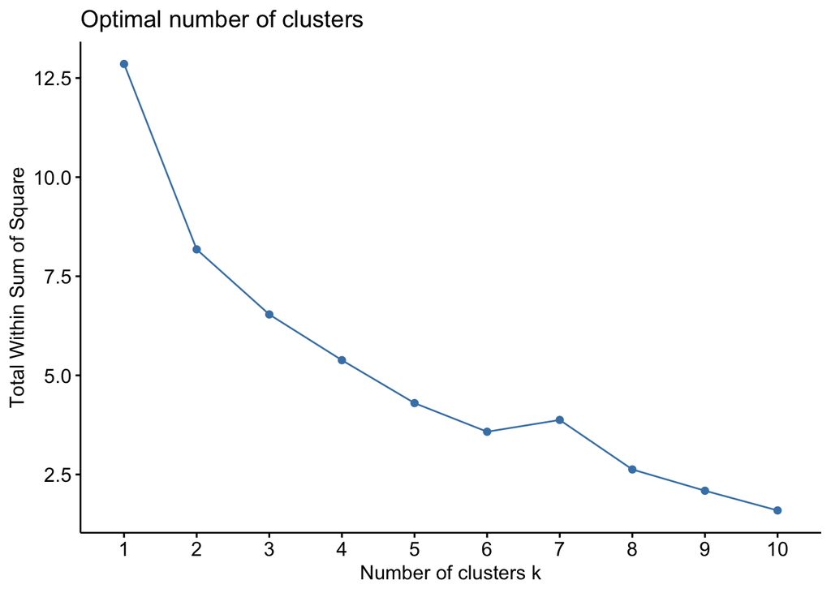

```r
fviz_nbclust(norm_predict, kmeans, method = "wss")
```

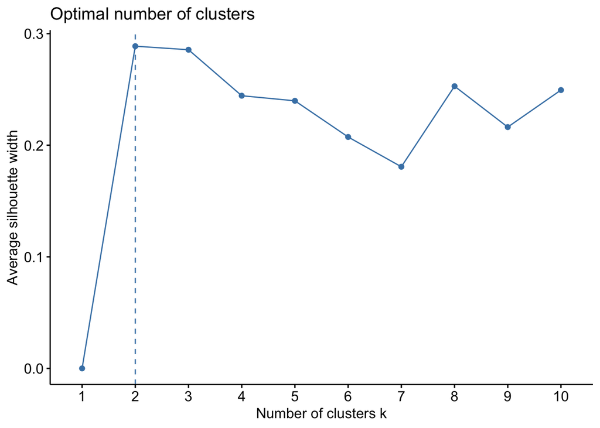

```r
fviz_nbclust(norm_predict, kmeans, method = "silhouette")
```

#From above we calculate kmeans optimal being k=2

```r
k_means_2 <- kmeans(norm_predict, centers = 2, nstart = 25)
k_means_2$centers
```

```
##   Market_Cap      Beta  PE_Ratio       ROE       ROA Asset_Turnover   Leverage
## 1 0.48580145 0.2727273 0.2199562 0.5389831 0.7171717         0.6250 0.09272209
## 2 0.06949161 0.4806452 0.3399240 0.1864407 0.2238095         0.3625 0.24843305
##   Rev_Growth Net_Profit_Margin
## 1  0.3567294         0.7673680
## 2  0.5368646         0.3567686
```

#Graphical representation of kmeans using cluster:

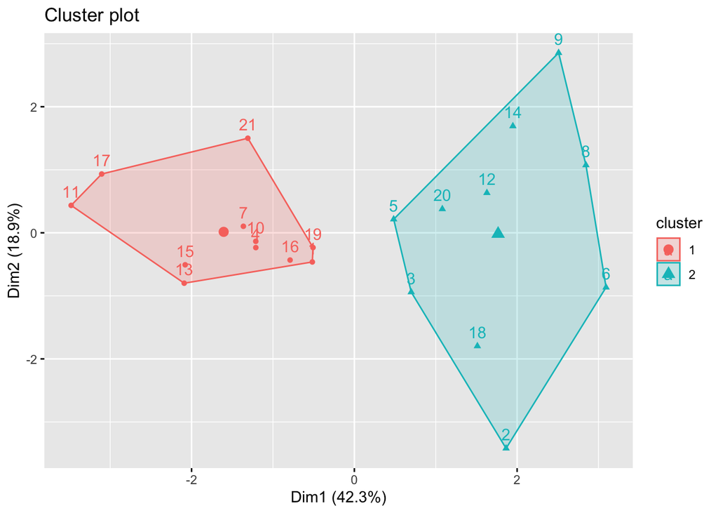

```r
fviz_cluster(k_means_2, data= norm_mean)
```

#Grouping of clusters with original data:

```r
k_cluster<- k_means_2$cluster
group_k <- cbind(pharma,k_cluster)
```

#Calculating mean for both clusters:

```r
aggregate(group_k[,-c(1,2,12:14)],by=list(group_k$k_cluster),FUN="mean")
```

| Group.1 | Market_Cap | Beta | PE_Ratio | ROE | ROA | Asset_Turnover | Leverage | Rev_Growth | Net_Profit_Margin | k_cluster |
| --- | --- | --- | --- | --- | --- | --- | --- | --- | --- | --- |
| 1 | 97.11364 | 0.4336364 | 20.95455 | 35.7 | 14.95455 | 0.80 | 0.3254545 | 10.16455 | 20.17273 | 1 |
| 2 | 14.24300 | 0.6270000 | 30.42000 | 14.9 | 5.63000 | 0.59 | 0.8720000 | 16.89800 | 10.77000 | 2 |

#Grouping of clusters with Original Data:

```r
groupk2<-cbind(group_k, pharma$Location,pharma$Exchange)
```

#c.Is there a pattern in the clusters with respect to the numerical variables (10 to 12)? #With respect to numerical values to columns (10 to 12) are as follows:

#Analysis under column 10.Mediation_recommendation: #Mediation_recommendation under cluster 1 consists- a) hold recommedations-6 , b) buy recommendations-3, c) sell recommendations - 2 ##Mediation_recommendation under cluster 2 consists- a) buy recommendations-5 , b) hold recommedations-3, c) sell recommendations - 2

#Analysis under columns 11.pharma$Location and 12.pharma$Exchange : #Majority of pharma locations in cluster-1 and cluster-2 are US- based and for pharma exchnage the mojority is NYSE for both the clusters.

#d.Naming for each cluster using any or all of the variables in the dataset: #Cluster 1- With majority mediation recommendations being hold, this cluster is named as “HOLD CLUSTER”. #Cluster 2- With majority mediation recommendations being buy, this cluster is named as “BUY CLUSTER”.